# Introduction

This project was created to learn basic techniques of data manipulation and machine learning. The idea is to use the dataset UCI_Credit_Card to improve basic skills of data cleaning, data analysis, data visualization and machine learning.

## Variables

There are 25 variables:

- ID: ID of each client
- LIMIT_BAL: Amount of given credit in NT dollars (includes individual and family/supplementary credit
- SEX: Gender (1=male, 2=female)
- EDUCATION: (1=graduate school, 2=university, 3=high school, 4=others, 5=unknown, 6=unknown)
- MARRIAGE: Marital status (1=married, 2=single, 3=others)
- AGE: Age in years
- PAY_0: Repayment status in September, 2005 (-1=pay duly, 1=payment delay for one month, 2=payment delay for two months, ... 8=payment delay for eight months, 9=payment delay for nine months and above)
- PAY_2: Repayment status in August, 2005 (scale same as above)
- PAY_3: Repayment status in July, 2005 (scale same as above)
- PAY_4: Repayment status in June, 2005 (scale same as above)
- PAY_5: Repayment status in May, 2005 (scale same as above)
- PAY_6: Repayment status in April, 2005 (scale same as above)
- BILL_AMT1: Amount of bill statement in September, 2005 (NT dollar)
- BILL_AMT2: Amount of bill statement in August, 2005 (NT dollar)
- BILL_AMT3: Amount of bill statement in July, 2005 (NT dollar)
- BILL_AMT4: Amount of bill statement in June, 2005 (NT dollar)
- BILL_AMT5: Amount of bill statement in May, 2005 (NT dollar)
- BILL_AMT6: Amount of bill statement in April, 2005 (NT dollar)
- PAY_AMT1: Amount of previous payment in September, 2005 (NT dollar)
- PAY_AMT2: Amount of previous payment in August, 2005 (NT dollar)
- PAY_AMT3: Amount of previous payment in July, 2005 (NT dollar)
- PAY_AMT4: Amount of previous payment in June, 2005 (NT dollar)
- PAY_AMT5: Amount of previous payment in May, 2005 (NT dollar)
- PAY_AMT6: Amount of previous payment in April, 2005 (NT dollar)
- default.payment.next.month: Default payment (1=yes, 0=no)

```python
import numpy as np
import pandas as pd
import matplotlib.pyplot as plt
import seaborn as sns
from ggplot import *
```

```python
df = pd.read_csv('UCI_Credit_Card.csv')
df.head()
```

|  | ID | LIMIT_BAL | SEX | EDUCATION | MARRIAGE | AGE | PAY_0 | PAY_2 | PAY_3 | PAY_4 | ... | BILL_AMT4 | BILL_AMT5 | BILL_AMT6 | PAY_AMT1 | PAY_AMT2 | PAY_AMT3 | PAY_AMT4 | PAY_AMT5 | PAY_AMT6 | default.payment.next.month |
| --- | --- | --- | --- | --- | --- | --- | --- | --- | --- | --- | --- | --- | --- | --- | --- | --- | --- | --- | --- | --- | --- |
| 0 | 1 | 20000.0 | 2 | 2 | 1 | 24 | 2 | 2 | -1 | -1 | ... | 0.0 | 0.0 | 0.0 | 0.0 | 689.0 | 0.0 | 0.0 | 0.0 | 0.0 | 1 |
| 1 | 2 | 120000.0 | 2 | 2 | 2 | 26 | -1 | 2 | 0 | 0 | ... | 3272.0 | 3455.0 | 3261.0 | 0.0 | 1000.0 | 1000.0 | 1000.0 | 0.0 | 2000.0 | 1 |
| 2 | 3 | 90000.0 | 2 | 2 | 2 | 34 | 0 | 0 | 0 | 0 | ... | 14331.0 | 14948.0 | 15549.0 | 1518.0 | 1500.0 | 1000.0 | 1000.0 | 1000.0 | 5000.0 | 0 |
| 3 | 4 | 50000.0 | 2 | 2 | 1 | 37 | 0 | 0 | 0 | 0 | ... | 28314.0 | 28959.0 | 29547.0 | 2000.0 | 2019.0 | 1200.0 | 1100.0 | 1069.0 | 1000.0 | 0 |
| 4 | 5 | 50000.0 | 1 | 2 | 1 | 57 | -1 | 0 | -1 | 0 | ... | 20940.0 | 19146.0 | 19131.0 | 2000.0 | 36681.0 | 10000.0 | 9000.0 | 689.0 | 679.0 | 0 |

5 rows × 25 columns

```python
df.info()
```

```
<class 'pandas.core.frame.DataFrame'>
RangeIndex: 30000 entries, 0 to 29999
Data columns (total 25 columns):
ID                            30000 non-null int64
LIMIT_BAL                     30000 non-null float64
SEX                           30000 non-null int64
EDUCATION                     30000 non-null int64
MARRIAGE                      30000 non-null int64
AGE                           30000 non-null int64
PAY_0                         30000 non-null int64
PAY_2                         30000 non-null int64
PAY_3                         30000 non-null int64
PAY_4                         30000 non-null int64
PAY_5                         30000 non-null int64
PAY_6                         30000 non-null int64
BILL_AMT1                     30000 non-null float64
BILL_AMT2                     30000 non-null float64
BILL_AMT3                     30000 non-null float64
BILL_AMT4                     30000 non-null float64
BILL_AMT5                     30000 non-null float64
BILL_AMT6                     30000 non-null float64
PAY_AMT1                      30000 non-null float64
PAY_AMT2                      30000 non-null float64
PAY_AMT3                      30000 non-null float64
PAY_AMT4                      30000 non-null float64
PAY_AMT5                      30000 non-null float64
PAY_AMT6                      30000 non-null float64
default.payment.next.month    30000 non-null int64
dtypes: float64(13), int64(12)
memory usage: 5.7 MB
```

# Data exploration

## check missing values

```python
df.isnull().sum()
```

```
ID                            0
LIMIT_BAL                     0
SEX                           0
EDUCATION                     0
MARRIAGE                      0
AGE                           0
PAY_0                         0
PAY_2                         0
PAY_3                         0
PAY_4                         0
PAY_5                         0
PAY_6                         0
BILL_AMT1                     0
BILL_AMT2                     0
BILL_AMT3                     0
BILL_AMT4                     0
BILL_AMT5                     0
BILL_AMT6                     0
PAY_AMT1                      0
PAY_AMT2                      0
PAY_AMT3                      0
PAY_AMT4                      0
PAY_AMT5                      0
PAY_AMT6                      0
default.payment.next.month    0
dtype: int64
```

there is no missing values

## check the data balance

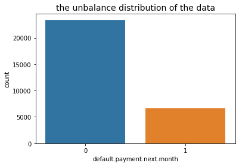

```python
sns.countplot('default.payment.next.month', data=df)
plt.title('the unbalance distribution of the data', fontsize=14)
```

It shows the data are highly imbalance, we need to deal with it later

## Exploring category varibales

```python
# Categorical variables description
df[['SEX', 'EDUCATION', 'MARRIAGE']].describe()
```

|  | SEX | EDUCATION | MARRIAGE |
| --- | --- | --- | --- |
| count | 30000.000000 | 30000.000000 | 30000.000000 |
| mean | 1.603733 | 1.853133 | 1.551867 |
| std | 0.489129 | 0.790349 | 0.521970 |
| min | 1.000000 | 0.000000 | 0.000000 |
| 25% | 1.000000 | 1.000000 | 1.000000 |
| 50% | 2.000000 | 2.000000 | 2.000000 |
| 75% | 2.000000 | 2.000000 | 2.000000 |
| max | 2.000000 | 6.000000 | 3.000000 |

EDUCATION has category 5 and 6 that are unlabelled, moreover the category 0 is undocumented. MARRIAGE has a label 0 that is undocumented

```python
# Payment delay description
df[['PAY_0', 'PAY_2', 'PAY_3', 'PAY_4', 'PAY_5', 'PAY_6']].describe()
```

|  | PAY_0 | PAY_2 | PAY_3 | PAY_4 | PAY_5 | PAY_6 |
| --- | --- | --- | --- | --- | --- | --- |
| count | 30000.000000 | 30000.000000 | 30000.000000 | 30000.000000 | 30000.000000 | 30000.000000 |
| mean | -0.016700 | -0.133767 | -0.166200 | -0.220667 | -0.266200 | -0.291100 |
| std | 1.123802 | 1.197186 | 1.196868 | 1.169139 | 1.133187 | 1.149988 |
| min | -2.000000 | -2.000000 | -2.000000 | -2.000000 | -2.000000 | -2.000000 |
| 25% | -1.000000 | -1.000000 | -1.000000 | -1.000000 | -1.000000 | -1.000000 |
| 50% | 0.000000 | 0.000000 | 0.000000 | 0.000000 | 0.000000 | 0.000000 |
| 75% | 0.000000 | 0.000000 | 0.000000 | 0.000000 | 0.000000 | 0.000000 |
| max | 8.000000 | 8.000000 | 8.000000 | 8.000000 | 8.000000 | 8.000000 |

Every negative value should be seen as a 0. But we will get to that later

```python
# Bill Statement description
df[['BILL_AMT1', 'BILL_AMT2', 'BILL_AMT3', 'BILL_AMT4', 'BILL_AMT5', 'BILL_AMT6']].describe()
```

|  | BILL_AMT1 | BILL_AMT2 | BILL_AMT3 | BILL_AMT4 | BILL_AMT5 | BILL_AMT6 |
| --- | --- | --- | --- | --- | --- | --- |
| count | 30000.000000 | 30000.000000 | 3.000000e+04 | 30000.000000 | 30000.000000 | 30000.000000 |
| mean | 51223.330900 | 49179.075167 | 4.701315e+04 | 43262.948967 | 40311.400967 | 38871.760400 |
| std | 73635.860576 | 71173.768783 | 6.934939e+04 | 64332.856134 | 60797.155770 | 59554.107537 |
| min | -165580.000000 | -69777.000000 | -1.572640e+05 | -170000.000000 | -81334.000000 | -339603.000000 |
| 25% | 3558.750000 | 2984.750000 | 2.666250e+03 | 2326.750000 | 1763.000000 | 1256.000000 |
| 50% | 22381.500000 | 21200.000000 | 2.008850e+04 | 19052.000000 | 18104.500000 | 17071.000000 |
| 75% | 67091.000000 | 64006.250000 | 6.016475e+04 | 54506.000000 | 50190.500000 | 49198.250000 |
| max | 964511.000000 | 983931.000000 | 1.664089e+06 | 891586.000000 | 927171.000000 | 961664.000000 |

```python
#Previous Payment Description
df[['PAY_AMT1', 'PAY_AMT2', 'PAY_AMT3', 'PAY_AMT4', 'PAY_AMT5', 'PAY_AMT6']].describe()
```

|  | PAY_AMT1 | PAY_AMT2 | PAY_AMT3 | PAY_AMT4 | PAY_AMT5 | PAY_AMT6 |
| --- | --- | --- | --- | --- | --- | --- |
| count | 30000.000000 | 3.000000e+04 | 30000.00000 | 30000.000000 | 30000.000000 | 30000.000000 |
| mean | 5663.580500 | 5.921163e+03 | 5225.68150 | 4826.076867 | 4799.387633 | 5215.502567 |
| std | 16563.280354 | 2.304087e+04 | 17606.96147 | 15666.159744 | 15278.305679 | 17777.465775 |
| min | 0.000000 | 0.000000e+00 | 0.00000 | 0.000000 | 0.000000 | 0.000000 |
| 25% | 1000.000000 | 8.330000e+02 | 390.00000 | 296.000000 | 252.500000 | 117.750000 |
| 50% | 2100.000000 | 2.009000e+03 | 1800.00000 | 1500.000000 | 1500.000000 | 1500.000000 |
| 75% | 5006.000000 | 5.000000e+03 | 4505.00000 | 4013.250000 | 4031.500000 | 4000.000000 |
| max | 873552.000000 | 1.684259e+06 | 896040.00000 | 621000.000000 | 426529.000000 | 528666.000000 |

```python
df.LIMIT_BAL.describe()
```

```
count      30000.000000
mean      167484.322667
std       129747.661567
min        10000.000000
25%        50000.000000
50%       140000.000000
75%       240000.000000
max      1000000.000000
Name: LIMIT_BAL, dtype: float64
```

```python
# revise the labels which is wrong
df = df.rename(columns={'default.payment.next.month': 'def_pay',
                        'PAY_0': 'PAY_1'})
```

```python
df.head()
```

|  | ID | LIMIT_BAL | SEX | EDUCATION | MARRIAGE | AGE | PAY_1 | PAY_2 | PAY_3 | PAY_4 | ... | BILL_AMT4 | BILL_AMT5 | BILL_AMT6 | PAY_AMT1 | PAY_AMT2 | PAY_AMT3 | PAY_AMT4 | PAY_AMT5 | PAY_AMT6 | def_pay |
| --- | --- | --- | --- | --- | --- | --- | --- | --- | --- | --- | --- | --- | --- | --- | --- | --- | --- | --- | --- | --- | --- |
| 0 | 1 | 20000.0 | 2 | 2 | 1 | 24 | 2 | 2 | -1 | -1 | ... | 0.0 | 0.0 | 0.0 | 0.0 | 689.0 | 0.0 | 0.0 | 0.0 | 0.0 | 1 |
| 1 | 2 | 120000.0 | 2 | 2 | 2 | 26 | -1 | 2 | 0 | 0 | ... | 3272.0 | 3455.0 | 3261.0 | 0.0 | 1000.0 | 1000.0 | 1000.0 | 0.0 | 2000.0 | 1 |
| 2 | 3 | 90000.0 | 2 | 2 | 2 | 34 | 0 | 0 | 0 | 0 | ... | 14331.0 | 14948.0 | 15549.0 | 1518.0 | 1500.0 | 1000.0 | 1000.0 | 1000.0 | 5000.0 | 0 |
| 3 | 4 | 50000.0 | 2 | 2 | 1 | 37 | 0 | 0 | 0 | 0 | ... | 28314.0 | 28959.0 | 29547.0 | 2000.0 | 2019.0 | 1200.0 | 1100.0 | 1069.0 | 1000.0 | 0 |
| 4 | 5 | 50000.0 | 1 | 2 | 1 | 57 | -1 | 0 | -1 | 0 | ... | 20940.0 | 19146.0 | 19131.0 | 2000.0 | 36681.0 | 10000.0 | 9000.0 | 689.0 | 679.0 | 0 |

5 rows × 25 columns

```python
# I am interested in having a general idea of the default probability
df.def_pay.sum() / len(df.def_pay)
```

```
0.2212
```

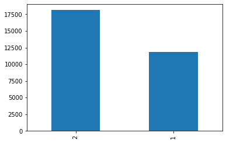

```python
df.SEX.value_counts().plot(kind = 'bar')
```

there are more women than men

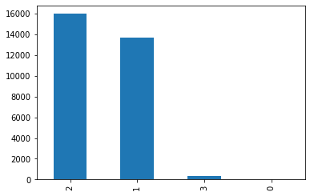

```python
df.MARRIAGE.value_counts().plot(kind = 'bar')
```

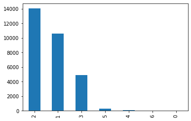

```python
df.EDUCATION.value_counts().plot(kind = 'bar')
```

It shows that the marriage and eduaction varibles need to be cleaned

## Numerical variables

```python
def draw_histograms(df, variables, n_rows, n_cols, n_bins):
    fig=plt.figure()
    for i, var_name in enumerate(variables):
        ax=fig.add_subplot(n_rows,n_cols,i+1)
        df[var_name].hist(bins=n_bins,ax=ax)
        ax.set_title(var_name)
    fig.tight_layout()  # Improves appearance a bit.
    plt.show()
```

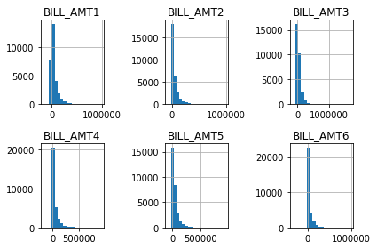

```python
bills = df[['BILL_AMT1','BILL_AMT2', 'BILL_AMT3', 'BILL_AMT4', 'BILL_AMT5', 'BILL_AMT6']]
draw_histograms(bills, bills.columns, 2, 3, 20)
```

```python
pay = df[['PAY_AMT1','PAY_AMT2', 'PAY_AMT3', 'PAY_AMT4', 'PAY_AMT5', 'PAY_AMT6']]
draw_histograms(pay, pay.columns, 2, 3, 20)
```

[output not shown]

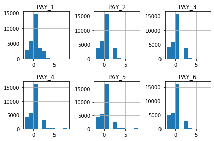

```python
late = df[['PAY_1','PAY_2', 'PAY_3', 'PAY_4', 'PAY_5', 'PAY_6']]
draw_histograms(late, late.columns, 2, 3, 10)

#this is probably more of a category
```

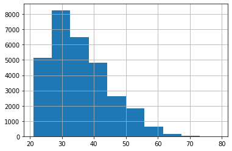

```python
df.AGE.hist()
```

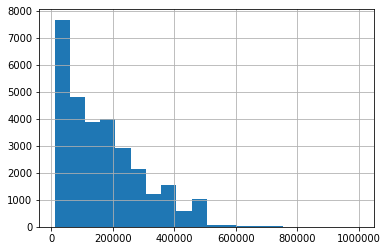

```python
df.LIMIT_BAL.hist(bins = 20)
```

# Data cleaning

As seen previously, some categories are mislabeled or undocumented. Before proceeding, it is time to fix it. The 0 in MARRIAGE can be safely categorized as 'Other' (thus 3). The 0 (undocumented), 5 and 6 (label unknown) in EDUCATION can also be put in a 'Other' cathegory (thus 4) Thus is a good occasion to learn how to use the .loc function.

"Other" in education can be an education lower than the high school level. "Other" in marriage could be, for example, "divorced".

```python
fil = (df.EDUCATION == 5) | (df.EDUCATION == 6) | (df.EDUCATION == 0)
df.loc[fil, 'EDUCATION'] = 4
df.EDUCATION.value_counts()
```

```
2    14030
1    10585
3     4917
4      468
Name: EDUCATION, dtype: int64
```

```python
df.loc[df.MARRIAGE == 0, 'MARRIAGE'] = 3
df.MARRIAGE.value_counts()
```

```
2    15964
1    13659
3      377
Name: MARRIAGE, dtype: int64
```

According to our documentation, the PAY_n variables indicate the number of months of delay and indicates "pay duly"with -1. Then what is -2? And what is 0? It seems to me the label has to be adjusted to 0 for pay duly.

```python
df.PAY_1.value_counts()
```

```
 0    14737
-1     5686
 1     3688
-2     2759
 2     2667
 3      322
 4       76
 5       26
 8       19
 6       11
 7        9
Name: PAY_1, dtype: int64
```

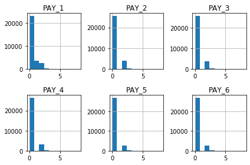

```python
fil = (df.PAY_1 == -2) | (df.PAY_1 == -1) | (df.PAY_1 == 0)
df.loc[fil, 'PAY_1'] = 0
fil = (df.PAY_2 == -2) | (df.PAY_2 == -1) | (df.PAY_2 == 0)
df.loc[fil, 'PAY_2'] = 0
fil = (df.PAY_3 == -2) | (df.PAY_3 == -1) | (df.PAY_3 == 0)
df.loc[fil, 'PAY_3'] = 0
fil = (df.PAY_4 == -2) | (df.PAY_4 == -1) | (df.PAY_4 == 0)
df.loc[fil, 'PAY_4'] = 0
fil = (df.PAY_5 == -2) | (df.PAY_5 == -1) | (df.PAY_5 == 0)
df.loc[fil, 'PAY_5'] = 0
fil = (df.PAY_6 == -2) | (df.PAY_6 == -1) | (df.PAY_6 == 0)
df.loc[fil, 'PAY_6'] = 0
late = df[['PAY_1','PAY_2', 'PAY_3', 'PAY_4', 'PAY_5', 'PAY_6']]
draw_histograms(late, late.columns, 2, 3, 10)
```

## check correlations

The goal is to see how relevant each feature is, what is its meaning, if it can be used to create new features

```python
gender = df.groupby(['SEX', 'def_pay']).size().unstack(1)
# 1 is the default for unstack, but I put it to show explicitly what we are unstacking
gender
```

| def_pay SEX | 0 | 1 |
| --- | --- | --- |
| 1 | 9015 | 2873 |
| 2 | 14349 | 3763 |

```python
gender['perc'] = (gender[1]/(gender[0] + gender[1]))
#this creates a new column in our dataset
gender
```

| def_pay SEX | 0 | 1 | perc |
| --- | --- | --- | --- |
| 1 | 9015 | 2873 | 0.241672 |
| 2 | 14349 | 3763 | 0.207763 |

Considering that about 22% of the customers will default, we see a couple of things:

- there are significantly more women than men
- men are most likely going to default the next month

However, we don't have to jump to any conclusion just yet since there might be some lurking variable that justifies the data better

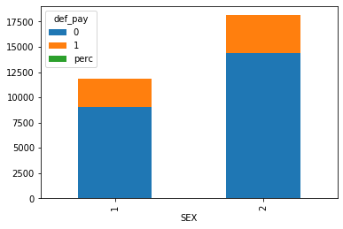

```python
gender.plot(kind='bar', stacked = True)
```

```python
def corr_2_cols(Col1, Col2):
    res = df.groupby([Col1, Col2]).size().unstack()
    res['perc'] = (res[res.columns[1]]/(res[res.columns[0]] + res[res.columns[1]]))
    return res
```

```python
corr_2_cols('EDUCATION', 'def_pay')
```

| def_pay EDUCATION | 0 | 1 | perc |
| --- | --- | --- | --- |
| 1 | 8549 | 2036 | 0.192348 |
| 2 | 10700 | 3330 | 0.237349 |
| 3 | 3680 | 1237 | 0.251576 |
| 4 | 435 | 33 | 0.070513 |

It seems that the higher is the education, the lower is the probability of defaulting the next month. Only exception is for the category labeled "Other" that, if we stick to the documentation, would be lower than high school. However, numerically they will not have much weight in the final result.

```python
corr_2_cols('MARRIAGE', 'def_pay')
```

| def_pay MARRIAGE | 0 | 1 | perc |
| --- | --- | --- | --- |
| 1 | 10453 | 3206 | 0.234717 |
| 2 | 12623 | 3341 | 0.209283 |
| 3 | 288 | 89 | 0.236074 |

All considered, these three categories seem to affect the result we want to predict.

How marital status or education can determine the balance of your credit card

```python
corr_2_cols('MARRIAGE', 'SEX')
```

| SEX MARRIAGE | 1 | 2 | perc |
| --- | --- | --- | --- |
| 1 | 5190 | 8469 | 0.620031 |
| 2 | 6553 | 9411 | 0.589514 |
| 3 | 145 | 232 | 0.615385 |

```python
corr_2_cols('EDUCATION', 'SEX')
```

| SEX EDUCATION | 1 | 2 | perc |
| --- | --- | --- | --- |
| 1 | 4354 | 6231 | 0.588663 |
| 2 | 5374 | 8656 | 0.616964 |
| 3 | 1990 | 2927 | 0.595282 |
| 4 | 170 | 298 | 0.636752 |

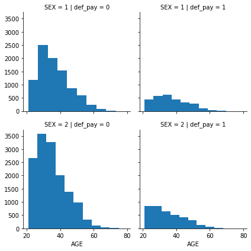

```python
g = sns.FacetGrid(df, col = 'def_pay', row = 'SEX')
g.map(plt.hist, 'AGE')
```

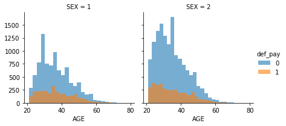

```python
g = sns.FacetGrid(df, col='SEX', hue='def_pay')
g.map(plt.hist, 'AGE', alpha=0.6, bins=25) #alpha is for opacity
g.add_legend()
```

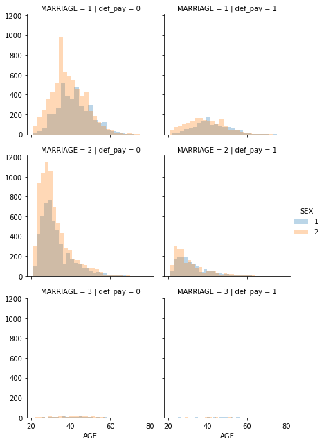

```python
g = sns.FacetGrid(df, col='def_pay', row= "MARRIAGE", hue='SEX')
g.map(plt.hist, 'AGE', alpha=0.3, bins=25)
g.add_legend()
```

This tells us that we can probably combine age with other categories to get a more descriptive feature

```python
df['SE_MA'] = df.SEX * df.MARRIAGE
corr_2_cols('SE_MA', 'def_pay')
```

[output not shown]

# Feature Engineering

Thus why not combine them in a single variable given by the product of the two?

I chose these two first because they are both labeled 1,2 and they both decrease the probability of defaulting if their value increase.

This operation will create a category for married man, which I expect to be the one with high probability of defaulting,

a combination of married women and single man, a category (expected to be numerically less populated) of "divorced" men (in other words, the "other" in marriage times the "male" in sex),

one for single women and one for "divorced" women.

```python
df['SE_MA_2'] = 0
df.loc[((df.SEX == 1) & (df.MARRIAGE == 1)) , 'SE_MA_2'] = 1 #married man
df.loc[((df.SEX == 1) & (df.MARRIAGE == 2)) , 'SE_MA_2'] = 2 #single man
df.loc[((df.SEX == 1) & (df.MARRIAGE == 3)) , 'SE_MA_2'] = 3 #divorced man
df.loc[((df.SEX == 2) & (df.MARRIAGE == 1)) , 'SE_MA_2'] = 4 #married woman
df.loc[((df.SEX == 2) & (df.MARRIAGE == 2)) , 'SE_MA_2'] = 5 #single woman
df.loc[((df.SEX == 2) & (df.MARRIAGE == 3)) , 'SE_MA_2'] = 6 #divorced woman
corr_2_cols('SE_MA_2', 'def_pay')
```

| def_pay SE_MA_2 | 0 | 1 | perc |
| --- | --- | --- | --- |
| 1 | 3844 | 1346 | 0.259345 |
| 2 | 5068 | 1485 | 0.226614 |
| 3 | 103 | 42 | 0.289655 |
| 4 | 6609 | 1860 | 0.219625 |
| 5 | 7555 | 1856 | 0.197216 |
| 6 | 185 | 47 | 0.202586 |

```python
del df['SE_MA_2']
df = df.rename(columns={'SE_MA_2': 'SE_MA'})
```

I like this better because I can see clearly that married men have a higher probability of defaulting, single men have nothing special with respect to the all population and single women have a lowe probability of defaulting. Among the divorced, men have more troubles (but these categories are not very much populated).

It can be useful to create age categories. We can do it in three ways (that I know of).

First, we could simply create a column and put a bunch of filters to fill it with the help of loc.

```python
df['AgeBin'] = pd.cut(df['AGE'], 6)
df.AgeBin.value_counts()
```

```
(20.942, 30.667]    11013
(30.667, 40.333]    10713
(40.333, 50.0]       6005
(50.0, 59.667]       1930
(59.667, 69.333]      314
(69.333, 79.0]         25
Name: AgeBin, dtype: int64
```

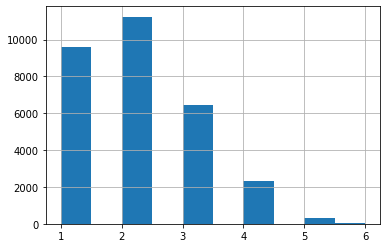

```python
df['AgeBin'] = 0 #creates a column of 0
df.loc[((df['AGE'] > 20) & (df['AGE'] < 30)) , 'AgeBin'] = 1
df.loc[((df['AGE'] >= 30) & (df['AGE'] < 40)) , 'AgeBin'] = 2
df.loc[((df['AGE'] >= 40) & (df['AGE'] < 50)) , 'AgeBin'] = 3
df.loc[((df['AGE'] >= 50) & (df['AGE'] < 60)) , 'AgeBin'] = 4
df.loc[((df['AGE'] >= 60) & (df['AGE'] < 70)) , 'AgeBin'] = 5
df.loc[((df['AGE'] >= 70) & (df['AGE'] < 81)) , 'AgeBin'] = 6
df.AgeBin.hist()
```

There are more people who are under 40 year old, there are least people over 70 years old.

We don't need all of them. The normal cut is easier to explain, but I need to get rid to the category 6 since it is not populated enough and can ruin the model. I will group it with the 5, effectively treating every client over 60 in the same way.

I will get rid of all the others.

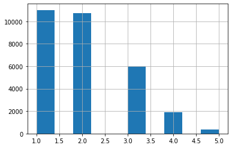

```python
df['AgeBin'] = pd.cut(df['AGE'], 6, labels = [1,2,3,4,5,6])
#because 1 2 3 ecc are "categories" so far and we need numbers
df['AgeBin'] = pd.to_numeric(df['AgeBin'])
df.loc[(df['AgeBin'] == 6) , 'AgeBin'] = 5
df.AgeBin.hist()
```

```python
corr_2_cols('AgeBin', 'def_pay')
```

| def_pay AgeBin | 0 | 1 | perc |
| --- | --- | --- | --- |
| 1 | 8542 | 2471 | 0.224371 |
| 2 | 8524 | 2189 | 0.204331 |
| 3 | 4606 | 1399 | 0.232973 |
| 4 | 1449 | 481 | 0.249223 |
| 5 | 243 | 96 | 0.283186 |

```python
corr_2_cols('AgeBin', 'SEX')
```

| SEX AgeBin | 1 | 2 | perc |
| --- | --- | --- | --- |
| 1 | 3842 | 7171 | 0.651140 |
| 2 | 4363 | 6350 | 0.592738 |
| 3 | 2587 | 3418 | 0.569192 |
| 4 | 917 | 1013 | 0.524870 |
| 5 | 179 | 160 | 0.471976 |

I see that default probability goes down in your 30's and then goes higher and higher.

At the same time, the percentage of men is growing with the age category. Thus I want to combine the two as before and create a combination of the two.

```python
df['SE_AG'] = 0
df.loc[((df.SEX == 1) & (df.AgeBin == 1)) , 'SE_AG'] = 1 #man in 20's
df.loc[((df.SEX == 1) & (df.AgeBin == 2)) , 'SE_AG'] = 2 #man in 30's
df.loc[((df.SEX == 1) & (df.AgeBin == 3)) , 'SE_AG'] = 3 #man in 40's
df.loc[((df.SEX == 1) & (df.AgeBin == 4)) , 'SE_AG'] = 4 #man in 50's
df.loc[((df.SEX == 1) & (df.AgeBin == 5)) , 'SE_AG'] = 5 #man in 60's and above
df.loc[((df.SEX == 2) & (df.AgeBin == 1)) , 'SE_AG'] = 6 #woman in 20's
df.loc[((df.SEX == 2) & (df.AgeBin == 2)) , 'SE_AG'] = 7 #woman in 30's
df.loc[((df.SEX == 2) & (df.AgeBin == 3)) , 'SE_AG'] = 8 #woman in 40's
df.loc[((df.SEX == 2) & (df.AgeBin == 4)) , 'SE_AG'] = 9 #woman in 50's
df.loc[((df.SEX == 2) & (df.AgeBin == 5)) , 'SE_AG'] = 10 #woman in 60's and above
corr_2_cols('SE_AG', 'def_pay')
```

| def_pay SE_AG | 0 | 1 | perc |
| --- | --- | --- | --- |
| 1 | 2929 | 913 | 0.237637 |
| 2 | 3350 | 1013 | 0.232180 |
| 3 | 1939 | 648 | 0.250483 |
| 4 | 666 | 251 | 0.273719 |
| 5 | 131 | 48 | 0.268156 |
| 6 | 5613 | 1558 | 0.217264 |
| 7 | 5174 | 1176 | 0.185197 |
| 8 | 2667 | 751 | 0.219719 |
| 9 | 783 | 230 | 0.227048 |
| 10 | 112 | 48 | 0.300000 |

I want something to describe the expenses of a client, following the idea I have expressed before when I looked at the BILL AMT and the PAY AMT. I am thinking of something like average expenses at any given month. Moreover, I want to give some context to it, so I will divide that number by LIMIT_BAL, so that we have a sort of extimation of how "careless" a client is.

```python
df['Avg_exp_5'] = ((df['BILL_AMT5'] - (df['BILL_AMT6'] - df['PAY_AMT5']))) / df['LIMIT_BAL']
df['Avg_exp_4'] = (((df['BILL_AMT5'] - (df['BILL_AMT6'] - df['PAY_AMT5'])) +
                 (df['BILL_AMT4'] - (df['BILL_AMT5'] - df['PAY_AMT4']))) / 2) / df['LIMIT_BAL']
df['Avg_exp_3'] = (((df['BILL_AMT5'] - (df['BILL_AMT6'] - df['PAY_AMT5'])) +
                 (df['BILL_AMT4'] - (df['BILL_AMT5'] - df['PAY_AMT4'])) +
                 (df['BILL_AMT3'] - (df['BILL_AMT4'] - df['PAY_AMT3']))) / 3) / df['LIMIT_BAL']
df['Avg_exp_2'] = (((df['BILL_AMT5'] - (df['BILL_AMT6'] - df['PAY_AMT5'])) +
                 (df['BILL_AMT4'] - (df['BILL_AMT5'] - df['PAY_AMT4'])) +
                 (df['BILL_AMT3'] - (df['BILL_AMT4'] - df['PAY_AMT3'])) +
                 (df['BILL_AMT2'] - (df['BILL_AMT3'] - df['PAY_AMT2']))) / 4) / df['LIMIT_BAL']
df['Avg_exp_1'] = (((df['BILL_AMT5'] - (df['BILL_AMT6'] - df['PAY_AMT5'])) +
                 (df['BILL_AMT4'] - (df['BILL_AMT5'] - df['PAY_AMT4'])) +
                 (df['BILL_AMT3'] - (df['BILL_AMT4'] - df['PAY_AMT3'])) +
                 (df['BILL_AMT2'] - (df['BILL_AMT3'] - df['PAY_AMT2'])) +
                 (df['BILL_AMT1'] - (df['BILL_AMT2'] - df['PAY_AMT1']))) / 5) / df['LIMIT_BAL']
df[['LIMIT_BAL', 'Avg_exp_5', 'BILL_AMT5', 'Avg_exp_4', 'BILL_AMT4','Avg_exp_3', 'BILL_AMT3',
    'Avg_exp_2', 'BILL_AMT2', 'Avg_exp_1', 'BILL_AMT1', 'def_pay']].sample(20)
```

|  | LIMIT_BAL | Avg_exp_5 | BILL_AMT5 | Avg_exp_4 | BILL_AMT4 | Avg_exp_3 | BILL_AMT3 | Avg_exp_2 | BILL_AMT2 | Avg_exp_1 | BILL_AMT1 | def_pay |
| --- | --- | --- | --- | --- | --- | --- | --- | --- | --- | --- | --- | --- |
| 26705 | 130000.0 | 0.020615 | 2573.0 | 0.015962 | 1462.0 | 0.015672 | 1958.0 | 0.016754 | 3548.0 | 0.015628 | 1439.0 | 0 |
| 22070 | 100000.0 | 0.022430 | 18299.0 | 0.015845 | 19225.0 | 0.014233 | 18726.0 | 0.035240 | 26226.0 | 0.042370 | 10693.0 | 0 |
| 27725 | 110000.0 | 0.000000 | 0.0 | 0.000000 | 0.0 | 0.000000 | 0.0 | 0.000000 | 0.0 | 0.000000 | 0.0 | 0 |
| 17139 | 50000.0 | 0.014640 | 45516.0 | 0.017820 | 46566.0 | 0.018880 | 45916.0 | 0.019250 | 44434.0 | 0.018228 | 41641.0 | 1 |
| 23223 | 300000.0 | 0.009497 | 113347.0 | 0.077447 | 152882.0 | 0.057906 | 152529.0 | 0.047066 | 149893.0 | 0.040575 | 147277.0 | 0 |
| 22871 | 340000.0 | 0.032321 | 140171.0 | 0.039057 | 150733.0 | 0.029971 | 149627.0 | 0.026808 | 155508.0 | 0.024443 | 160596.0 | 1 |
| 9147 | 50000.0 | 0.005180 | 3871.0 | 0.002590 | 71.0 | 0.001727 | 71.0 | 0.001295 | 0.0 | 0.001036 | 0.0 | 1 |
| 19853 | 420000.0 | 0.000000 | 0.0 | 0.000000 | 0.0 | 0.000000 | 0.0 | 0.000000 | 0.0 | 0.000000 | 0.0 | 1 |
| 16516 | 150000.0 | 0.062127 | 56995.0 | 0.093457 | 73688.0 | 0.079796 | 78407.0 | 0.098443 | 81537.0 | 0.088837 | 84034.0 | 0 |
| 19765 | 50000.0 | 0.007520 | 28390.0 | 0.222580 | 49336.0 | 0.155707 | 47652.0 | 0.138005 | 49799.0 | 0.114936 | 50932.0 | 0 |
| 1176 | 50000.0 | 0.005840 | 17581.0 | 0.005670 | 17056.0 | 0.005613 | 16431.0 | 0.007025 | 15694.0 | 0.007788 | 14536.0 | 0 |
| 7536 | 300000.0 | 0.000000 | 0.0 | 0.000965 | 579.0 | 0.003932 | 2960.0 | 0.004374 | 1706.0 | 0.005422 | 2884.0 | 1 |
| 11904 | 10000.0 | 0.000000 | 0.0 | 0.000000 | 0.0 | 0.000000 | 0.0 | 0.000000 | 0.0 | 0.198000 | 9900.0 | 1 |
| 3690 | 180000.0 | 0.000000 | 0.0 | 0.021200 | 7632.0 | 0.014133 | 0.0 | 0.149489 | 100000.0 | 0.119591 | 0.0 | 0 |
| 19358 | 160000.0 | 0.013319 | 136809.0 | 0.060000 | 149053.0 | 0.048169 | 147184.0 | 0.042664 | 151368.0 | 0.038935 | 147710.0 | 0 |
| 319 | 180000.0 | 0.000000 | -2.0 | 0.000000 | -2.0 | 0.000000 | -2.0 | 0.000000 | -2.0 | 0.000000 | -2.0 | 0 |
| 17805 | 220000.0 | 0.059273 | 12826.0 | 0.074873 | 19867.0 | 0.079450 | 19303.0 | 0.082102 | 19053.0 | 0.081032 | 15872.0 | 0 |
| 20752 | 420000.0 | 0.058686 | 24648.0 | 0.038015 | 23933.0 | 0.041005 | 19725.0 | 0.046446 | 24671.0 | 0.043451 | 13218.0 | 0 |
| 4184 | 350000.0 | 0.002526 | 23900.0 | 0.002484 | 23755.0 | 0.002616 | 23263.0 | 0.002692 | 22585.0 | 0.002727 | 23589.0 | 0 |
| 11750 | 50000.0 | 0.013280 | 19845.0 | 0.009600 | 19437.0 | 0.497913 | 53278.0 | 0.401080 | 56454.0 | 0.341648 | 59321.0 | 0 |

```
One last thing: how far the bill is from the limit should matter, thus I will create that variable.
Since the result can vary a lot from one client to the other (the LIMIT_BAL variable has a very wide range),
I will again weight this difference on the LIMIT_BAL feature (in my mind it has more meaning, maybe I am wrong).
Again, I want to keep the historical trend of the variable
```

```python
df['Closeness_6'] = (df.LIMIT_BAL - df.BILL_AMT6) / df.LIMIT_BAL
df['Closeness_5'] = (df.LIMIT_BAL - df.BILL_AMT5) / df.LIMIT_BAL
df['Closeness_4'] = (df.LIMIT_BAL - df.BILL_AMT4) / df.LIMIT_BAL
df['Closeness_3'] = (df.LIMIT_BAL - df.BILL_AMT3) / df.LIMIT_BAL
df['Closeness_2'] = (df.LIMIT_BAL - df.BILL_AMT2) / df.LIMIT_BAL
df['Closeness_1'] = (df.LIMIT_BAL - df.BILL_AMT1) / df.LIMIT_BAL
df[['Closeness_6', 'Closeness_5', 'Closeness_4', 'Closeness_3', 'Closeness_2',
   'Closeness_1', 'def_pay']].sample(20)
```

|  | Closeness_6 | Closeness_5 | Closeness_4 | Closeness_3 | Closeness_2 | Closeness_1 | def_pay |
| --- | --- | --- | --- | --- | --- | --- | --- |
| 5280 | 1.000000 | 1.000000 | -0.335200 | 0.864800 | 0.680800 | 0.136600 | 0 |
| 16792 | 0.240700 | 0.223700 | 0.201300 | 0.178900 | 0.340500 | 0.386600 | 0 |
| 14183 | 0.828956 | 0.831018 | 0.832734 | 0.818022 | 0.816436 | 0.820852 | 0 |
| 10610 | 0.395160 | 0.382360 | 0.528720 | 0.535000 | 0.555280 | 0.581860 | 0 |
| 19711 | 0.973514 | 0.974691 | 0.973605 | 0.980532 | 0.979600 | 0.978659 | 1 |
| 3650 | 0.778457 | 0.783236 | 0.747421 | 0.725589 | 0.729046 | 0.704675 | 0 |
| 26601 | 0.798600 | 0.815820 | 0.823140 | 0.844340 | 0.866080 | 0.888020 | 0 |
| 20072 | 0.890674 | 0.895291 | 0.898791 | 0.909761 | 0.921465 | 0.921926 | 0 |
| 23823 | 1.000000 | 0.990738 | 0.996162 | 1.000000 | 1.000000 | 0.992567 | 0 |
| 17013 | 0.146600 | 0.411667 | 0.242633 | 0.125033 | 0.113667 | 0.099567 | 0 |
| 3046 | 0.062285 | 0.049364 | 0.070448 | 0.087076 | 0.139809 | 0.121564 | 0 |
| 15886 | 1.000000 | 0.997000 | 0.994000 | 0.991000 | 0.991462 | 0.993331 | 0 |
| 22032 | 0.206440 | 0.392000 | 0.492820 | 0.569720 | 0.717020 | 0.798980 | 0 |
| 29867 | 0.211012 | 0.224985 | 0.156882 | 0.025488 | 0.024585 | 0.868074 | 0 |
| 13205 | 0.991641 | 0.986700 | 0.986941 | 0.990566 | 0.990828 | 0.954575 | 0 |
| 5874 | 0.062340 | 0.111010 | 0.027730 | 0.075690 | 0.022490 | -0.013260 | 1 |
| 25469 | 1.000000 | 0.333333 | 0.346667 | 0.380000 | 0.413333 | 0.446667 | 0 |
| 26619 | 0.089000 | 0.092100 | 0.156900 | 0.128300 | 0.359000 | 0.476800 | 1 |
| 4516 | 0.162800 | 0.081363 | 0.121463 | 0.050338 | 0.158362 | 0.207900 | 0 |
| 17608 | 0.796986 | 0.795671 | 0.806943 | 0.687600 | 0.180000 | 0.156857 | 0 |

## feature selection and balance the data

There are 2 "methods" of doing so:

```
by appropriately sampling my training data and by using the right algorithm.
```

First, I decide which features I want to include in my models and split the data into training and testing set.

```python
from sklearn.tree import DecisionTreeClassifier
from sklearn.ensemble import RandomForestClassifier , GradientBoostingClassifier, AdaBoostClassifier
from xgboost import XGBClassifier
from sklearn.metrics import f1_score
from sklearn.model_selection import GridSearchCV
from imblearn.over_sampling import SMOTE
from sklearn.model_selection import train_test_split
from sklearn.metrics import accuracy_score, make_scorer
```

```python
features = ['LIMIT_BAL', 'EDUCATION', 'MARRIAGE', 'PAY_1','PAY_2', 'PAY_3',
            'PAY_4', 'PAY_5', 'PAY_6','BILL_AMT1', 'BILL_AMT2',
            'BILL_AMT3', 'BILL_AMT4', 'BILL_AMT5', 'BILL_AMT6', 'PAY_AMT1',
            'PAY_AMT2', 'PAY_AMT3', 'PAY_AMT4', 'PAY_AMT5', 'PAY_AMT6',
            'SE_MA', 'AgeBin', 'SE_AG', 'Avg_exp_5', 'Avg_exp_4',
            'Avg_exp_3', 'Avg_exp_2', 'Avg_exp_1', 'Closeness_5',
            'Closeness_4', 'Closeness_3', 'Closeness_2','Closeness_1']
y = df['def_pay'].copy() # target
X = df[features].copy()
X_train, X_test, y_train, y_test = train_test_split(X, y, test_size=0.20, random_state=42)
```

Within my train dataset I still have a certain unbalance in the target class, thus I can do the following:

- I don't care, I will just pick the best model
- I upsample the minority class
- I downsample the majority class
- I create a syntetic sample
- I will a syntetic sample to use the SMOTE algorithm, which is an oversampling method which creates syntetic samples from the minority class instead of creating copies. It selects 2 or more similar instances and perturb them one at a time by random amount. This techniques should avoid overfitting problems but it risks adding noise to the model

```python
sm = SMOTE(random_state=589, ratio = 1.0)
X_SMOTE, y_SMOTE = sm.fit_sample(X_train, y_train)
print(len(y_SMOTE))
print(y_SMOTE.sum())
```

[output not shown]

I have divide the training data into X_SMOTE, y_SMOTE， Next, I will use the smote data to do :

```
- K-fold evaluation, run on different models should give us an idea on
   which one is more stable towards splitting of train and test
- Hyperparameter selection, so that we can have the best version of every algorithm
- Training
- Testing
```

How to evaluate?

Accuracy is not good for unbalanced data, we will use f1 metric and false negative rate to detect it

## Algorithm Selection

A very common and profitable technique is to use ensambles: combinations of different classifiers that create a more robust model. The basic predictor will be again a Decision tree and I will test a few different ensambles.

The main "classes" are:

- baggin ensambles: which reduce the chances of overfitting by running a series of unconstrained learners in parallel and combine them
- boosting ensambles: which improve the the flexibility of simple models by running a series of constrained learners in sequence. Each one of them will learn from the mistakes of the previous one. At the end it combines them in one unconstrained learner

As a bagging ensambles: I choose Random Forest. It trains on a large number of trees and combine them. The randomness comes from the fact that each tree is allowed to choose from a random subset of features to split on and each tree is trained on a random subset of observations.

The first boosting ensamble I choose the Gradient Tree Boosting. It tries to minimize a loss function (difference between the real value and output of the learner) using the gradient descent method. Then there is Ada-Boost that trains the learners to make strong prediction by focusing on examples harder and harder to classify. This is done by assigning weights to the instances and increasing the one of missclassified one.

## Training

### Random Forest with different samples

```python
# SMOTE training set
param_grid = {'n_estimators': [200, 400, 600, 1000],
              'criterion': ['entropy', 'gini'], 'n_jobs' : [-1]}
acc_scorer = make_scorer(f1_score)
grid_forest = GridSearchCV(RandomForestClassifier(), param_grid, scoring = acc_scorer, cv=5)
%time grid_forest = grid_forest.fit(X_SMOTE, y_SMOTE)
print(grid_forest.best_estimator_)
print(grid_forest.best_score_)
forest_SMOTE = grid_forest.best_estimator_
```

```python
forest_SMOTE = RandomForestClassifier(bootstrap=True, class_weight=None, criterion='gini',
            max_depth=None, max_features='auto', max_leaf_nodes=None,
            min_impurity_decrease=0.0, min_impurity_split=None,
            min_samples_leaf=1, min_samples_split=2,
            min_weight_fraction_leaf=0.0, n_estimators=600, n_jobs=-1,
            oob_score=False, random_state=None, verbose=0,
            warm_start=False)
print(0.831423121548)
```

### Ada Boost Classifier

```python
# SMOTE training set
param_grid = {'n_estimators': [200,300],
              'algorithm': ['SAMME', 'SAMME.R'],
              'learning_rate' : [0.5, 0.75, 1.0]}
acc_scorer = make_scorer(f1_score)
grid_ada = GridSearchCV(AdaBoostClassifier(), param_grid, scoring = acc_scorer, cv=5)
%time grid_ada = grid_ada.fit(X_SMOTE, y_SMOTE)
print(grid_ada.best_estimator_)
print(grid_ada.best_score_)
ada_SMOTE = grid_ada.best_estimator_
```

```python
ada_SMOTE = AdaBoostClassifier(algorithm='SAMME', base_estimator=None, learning_rate=0.5,
          n_estimators=200, random_state=None)
print(0.797835003041)
```

### Gradient Boost

```python
#SMOTE training set
param_grid = {'n_estimators': [200,300],
              'learning_rate' : [0.5, 0.75, 1.0]}
acc_scorer = make_scorer(f1_score)
grid_gbc = GridSearchCV(GradientBoostingClassifier(), param_grid, scoring = acc_scorer, cv=5)
%time grid_gbc = grid_gbc.fit(X_SMOTE, y_SMOTE)
print(grid_gbc.best_estimator_)
print(grid_gbc.best_score_)
gbc_SMOTE = grid_gbc.best_estimator_
```

```python
gbc_SMOTE = GradientBoostingClassifier(criterion='friedman_mse', init=None,
              learning_rate=0.5, loss='deviance', max_depth=3,
              max_features=None, max_leaf_nodes=None,
              min_impurity_decrease=0.0, min_impurity_split=None,
              min_samples_leaf=1, min_samples_split=2,
              min_weight_fraction_leaf=0.0, n_estimators=200,
              presort='auto', random_state=None, subsample=1.0, verbose=0,
              warm_start=False)
print(0.78976849349)
```

```python
data = {'model':['Random Forest', 'Ada Boost', 'Gradient Boost'], 'F1_score':[0.831, 0.798, 0.790]}
```

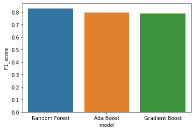

```python
tmp = pd.DataFrame(data)
tmp = tmp.sort_values(by='F1_score',ascending=False)
sns.barplot(x='model',y='F1_score',data = tmp)
```

It seems random forest gives the highest f1 score,they may fall into the overfitting trap more often, so we will see how they perform on the test data.

## Testing

```python
#Random forest
%time forest_SMOTE.fit(X_SMOTE, y_SMOTE)
predictions = forest_SMOTE.predict(X_test)
print("-------------")
print("f1 score: {}".format(round(f1_score(y_true = y_test, y_pred = predictions),3)))
print("Accuracy: {}".format(round(accuracy_score(y_true = y_test, y_pred = predictions),3)))
print("-------------")
print(get_feature_importance(forest_SMOTE, features))
print("-------------")
TP = np.sum(np.logical_and(predictions == 1, y_test == 1))
TN = np.sum(np.logical_and(predictions == 0, y_test == 0))
FP = np.sum(np.logical_and(predictions == 1, y_test == 0))
FN = np.sum(np.logical_and(predictions == 0, y_test == 1))
pred = len(predictions)

print('True Positives: {}'.format(TP))
print('False Positive: {}'.format(FP))
print('True Negative: {}'.format(TN))
print('False Negative: {}'.format(FN))
print('Precision: {}'.format(round(TP/(TP+FP),2)))
print('Recall: {}'.format(round(TP/(TP+FN),2)))
print('Problematic ratio: {}'.format(round(FN/(FN+TP),2)))
```

[output not shown]

```python
# ada boosting
%time ada_SMOTE.fit(X_SMOTE, y_SMOTE)
predictions = ada_SMOTE.predict(X_test)
print("-------------")
print("f1 score: {}".format(round(f1_score(y_true = y_test, y_pred = predictions),3)))
print("Accuracy: {}".format(round(accuracy_score(y_true = y_test, y_pred = predictions),3)))
print("-------------")
print(get_feature_importance(ada_SMOTE, features))
print("-------------")
TP = np.sum(np.logical_and(predictions == 1, y_test == 1))
TN = np.sum(np.logical_and(predictions == 0, y_test == 0))
FP = np.sum(np.logical_and(predictions == 1, y_test == 0))
FN = np.sum(np.logical_and(predictions == 0, y_test == 1))
pred = len(predictions)

print('True Positives: {}'.format(TP))
print('False Positive: {}'.format(FP))
print('True Negative: {}'.format(TN))
print('False Negative: {}'.format(FN))
print('Precision: {}'.format(round(TP/(TP+FP),2)))
print('Recall: {}'.format(round(TP/(TP+FN),2)))
print('Problematic ratio: {}'.format(round(FN/(FN+TP),2)))
```

[output not shown]

```python
# Gradient boost
%time gbc_SMOTE.fit(X_SMOTE, y_SMOTE)
predictions = gbc_SMOTE.predict(X_test)
print("-------------")
print("f1 score: {}".format(round(f1_score(y_true = y_test, y_pred = predictions),3)))
print("Accuracy: {}".format(round(accuracy_score(y_true = y_test, y_pred = predictions),3)))
print("-------------")
print(get_feature_importance(gbc_SMOTE, features))
print("-------------")
TP = np.sum(np.logical_and(predictions == 1, y_test == 1))
TN = np.sum(np.logical_and(predictions == 0, y_test == 0))
FP = np.sum(np.logical_and(predictions == 1, y_test == 0))
FN = np.sum(np.logical_and(predictions == 0, y_test == 1))
pred = len(predictions)

print('True Positives: {}'.format(TP))
print('False Positive: {}'.format(FP))
print('True Negative: {}'.format(TN))
print('False Negative: {}'.format(FN))
print('Precision: {}'.format(round(TP/(TP+FP),2)))
print('Recall: {}'.format(round(TP/(TP+FN),2)))
print('Problematic ratio: {}'.format(round(FN/(FN+TP),2))
```

[output not shown]

### summarize the result

- Random forest: f1_score: 0.486; problematic ratio: 0.59
- Ada_boost: f1_score:0.479; problematic ratio: 0.58
- Gradient boost: f1_score:0.453; problematic ratio: 0.62

# Further improvement:

- I have evaluated everything with a generally good indicator (the f1-score) Setting a specific goal would have directed this notebook in a more specific direction. For example, if the interest of a bank is to predict the default of its clients, it might be better to use a model less incline to return false negatives.  
  However, if the bank (and it is most likely the case) will invest resources to prevent the default of its clients, the role of false positives will become more and more relevant. Thus it can be a nice thing to define a cost function myself, which would take into account the cost of TP, FP, TN, and FN, and train my models in order to minimize it.
- reduce the feature to analyze